# Simplifying Predictive Models Using Body Information: A Study on Body Fat Estimation

Group L01G02

Ethan Cunanan, Jerry Jin, Johan Kok, Tingwei Liang, Tyler Sitchon

```r
# hide package warning and message to keep the report concise
knitr::opts_chunk$set(warning = FALSE, message = FALSE)
```

```r
#Data Import
library(tidyverse)
library(knitr)

data = read.table("data/bodyfat.txt", header = TRUE, sep = "\t")
```

# 1 Data description

First look at the data relationship

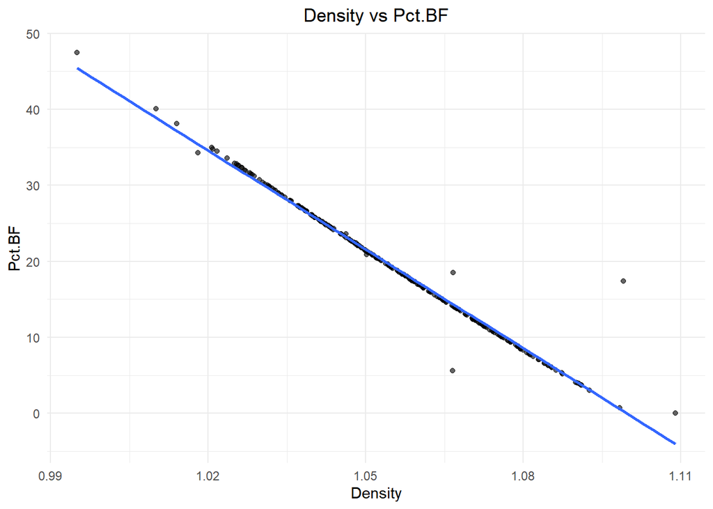

```r
library(ggplot2)

ggplot(data, aes(x = Density, y = Pct.BF)) +
  geom_point(alpha = 0.6) +
  geom_smooth(method = "lm", se = FALSE) +
  labs(title = "Density vs Pct.BF",
       x = "Density",
       y = "Pct.BF") +
  theme_minimal() +
  theme(plot.title = element_text(hjust = 0.5)) +
  scale_fill_brewer(palette="Pastel1")
```

The presence of outliers necessitates the reassignment of values based on the established formula. Density is directly measured using the weight in air and the weight in water, while Pct.BF is derived from Density through the equation. This analysis emphasizes that Density is a more reliable metric; thus, we opt to reassign the value accordingly.

```r
data$Predicted_Pct_BF <- round(495 / data$Density - 450, 2)


data$Pct.BF <- ifelse(data$Predicted_Pct_BF != round(data$Pct.BF, 2),
                      data$Predicted_Pct_BF,
                      data$Pct.BF)

data$Predicted_Pct_BF <- NULL
```

Furthermore, two anomalies were identified in the dataset. According to the original experiment conducted by Johnson (1996), the body density of the human body typically falls within the range of 0.900 to 1.100 g/cm³. However, two data points were found to lie outside this range, suggesting potential errors in manual recording. Consequently, these two outlier data points were removed from the analysis to maintain the integrity of the dataset.

```r
data <- data[data$Density >= 0.900 & data$Density <= 1.100, ]
```

Recheck the graph.

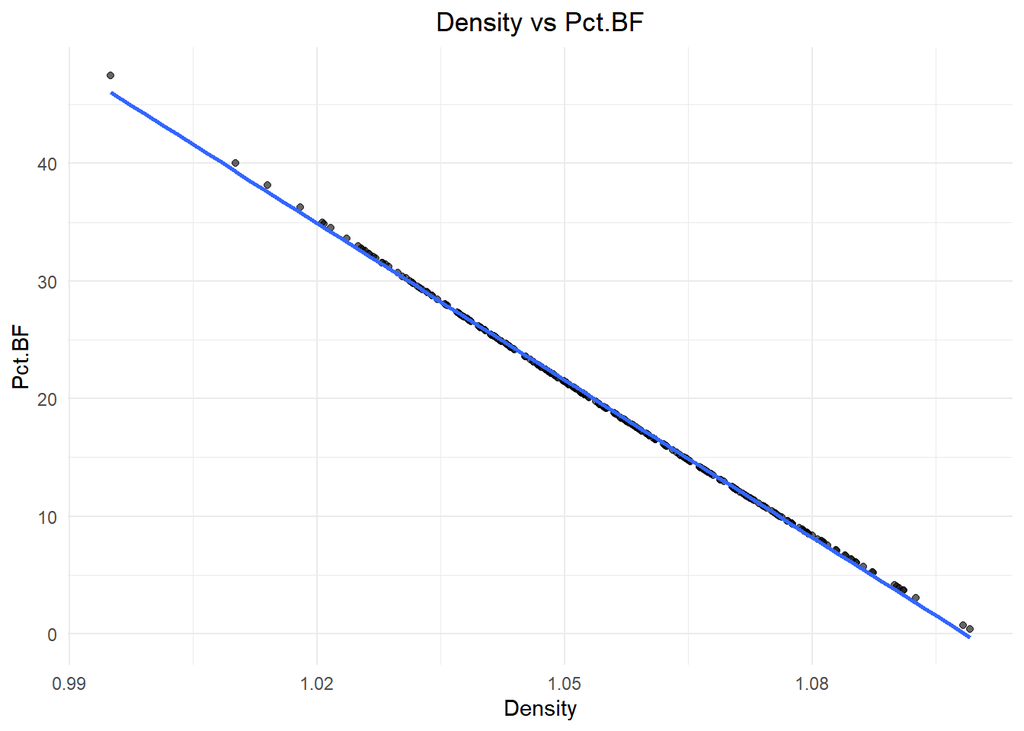

```r
ggplot(data, aes(x = Density, y = Pct.BF)) +
  geom_point(alpha = 0.6) +
  geom_smooth(method = "lm", se = FALSE) +
  labs(title = "Density vs Pct.BF",
       x = "Density",
       y = "Pct.BF") +
  theme_minimal() +
  theme(plot.title = element_text(hjust = 0.5)) +
  scale_fill_brewer(palette="Pastel1")
```

View relationships with other variables

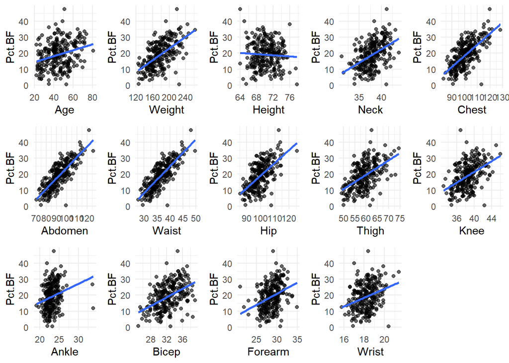

```r
library(ggplot2)
library(gridExtra)

plots <- list()

variables <- c("Age", "Weight", "Height", "Neck", "Chest",
               "Abdomen", "Waist", "Hip", "Thigh", "Knee",
               "Ankle", "Bicep", "Forearm", "Wrist")

for (var in variables) {
  p <- ggplot(data, aes_string(x = var, y = "Pct.BF")) +
    geom_point(alpha = 0.6) +
    geom_smooth(method = "lm", se = FALSE) +
    labs(x = var,
         y = "Pct.BF") +
    theme_minimal() +
    theme(plot.title = element_text(hjust = 0.5))
  plots[[var]] <- p
}

grid.arrange(grobs = plots, ncol = 5)
```

**1. Strong Positive Correlation**

The following variables exhibit a significant positive correlation with percent body fat, indicating that as their values increase, so does the percentage of body fat:

- **Weight**: The points are densely distributed, and the regression line has a steep slope, indicating a significant positive correlation.
- **Abdomen**: The points are tightly clustered, and the regression line has a steep slope, making it one of the strongest variables related to body fat percentage.
- **Chest**: There is a strong positive correlation with body fat percentage, and the data points are also relatively concentrated.

**2. Weak Positive Correlation**

**3. No Significant or Negative Correlation**

Certain variables exhibit no significant correlation with body fat percentage, and some may even show a slight negative correlation:

- **Height**: There is almost no correlation, with a flat regression line and a very scattered distribution of data points.
- **Ankle**: There is nearly no correlation with body fat percentage, and the data points are extremely dispersed.

A heat map was then used to see the correlation between the variables

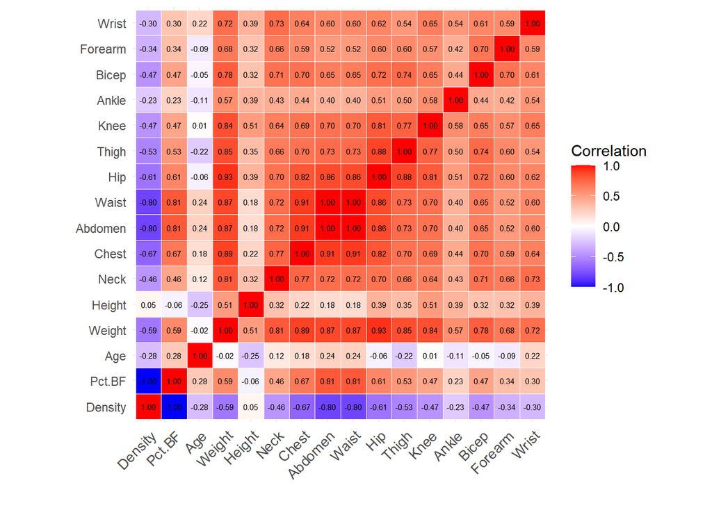

```r
library(ggplot2)
library(reshape2)

cor_matrix <- cor(data, use = "complete.obs")

melted_cor_matrix <- melt(cor_matrix)

ggplot(data = melted_cor_matrix, aes(x = Var1, y = Var2, fill = value)) +
  geom_tile(color = "white") +
  scale_fill_gradient2(low = "blue", high = "red", mid = "white",
                       midpoint = 0, limit = c(-1, 1), space = "Lab",
                       name = "Correlation") +
  theme_minimal() +
  theme(axis.text.x = element_text(angle = 45, vjust = 1,
                                   size = 10, hjust = 1)) +
  coord_fixed() +
  geom_text(aes(Var1, Var2, label = sprintf("%.2f", round(value, 2))),
            color = "black", size = 2) +
  labs(x = '', y = '')
```

**Main Correlations Between Variables**

**Multicollinearity** Multicollinearity is a high degree of correlation between two or more independent variables, which may lead to instability and difficulty in interpreting the results of regression analysis. To detect multicollinearity, we can use Variance Inflation Factor (VIF) to assess it.

The VIF results indicate a singularity between abdomen and waist **(Error: vif.default(model): there are aliased coefficients in the model)**, suggesting that these two variables are completely linearly related, leading to unstable model parameters and even making estimation impossible. In practical measurement, the waist is measured at a relatively fixed position, typically at the narrowest point just below the rib cage and above the iliac crest, with clear measurement standards. In contrast, the abdomen is measured at its widest point, which can be influenced by factors such as breathing, posture, and fat distribution, making it prone to errors. Therefore, we have decided to retain the waist data and delete the abdomen data to resolve this issue.

```r
library(car)

data <- data[, !names(data) %in% "Abdomen"]

model <- lm(Pct.BF ~ ., data = data)

vif_values <- vif(model)
print(vif_values)
```

```
##   Density       Age    Weight    Height      Neck     Chest     Waist       Hip
##  3.786650  2.311391 44.995270  3.490714  3.971822 10.755612 16.955603 11.995351
##     Thigh      Knee     Ankle     Bicep   Forearm     Wrist
##  7.116264  4.357358  1.802356  3.421894  2.408170  3.396697
```

Based on the output Variance Inflation Factor (VIF) values, we can identify which variables may be exhibiting multicollinearity issues. Typically, a VIF value exceeding 10 suggests the presence of multicollinearity, indicating that further intervention is necessary. This may involve removing highly correlated variables or employing regularization techniques, such as LASSO regression, to address the multicollinearity concerns.

# 2 Experiment 1: Direct Prediction of Pct.BF Using Other Body Data

## 2.1 Assumption checking

Comparison was done using direct and regularization (to reduce the effect of covariance) respectively

```r
library(caret)

data_test1 <- data %>% select(-Density)

model <- lm(Pct.BF ~ ., data = data_test1)
```

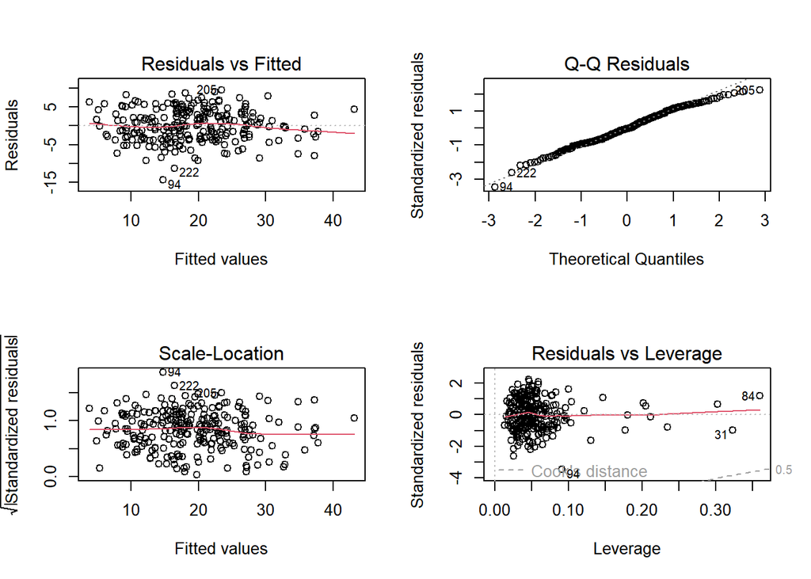

```r
# residual plot
par(mfrow = c(2, 2))
plot(model)
```

**1. Residuals vs. Fitted Values**

The figure shows the relationship between residuals and fitted values. Ideally, the residuals should be evenly distributed around zero without any clear pattern. The plot indicates that the residuals exhibit significant fluctuations and that there is no heteroscedasticity, consistent with the assumption of homoscedasticity.

**2. Q-Q Plot**

The Q-Q plot is used to assess the normality of residuals. If the points closely follow the 45-degree line, it suggests that the residuals are normally distributed. The plot shows that the residuals are generally consistent with a normal distribution.

**3. Scale-Location Plot**

**4. Residuals vs. Leverage**

**Concerns**

```r
# Using OLS as a model benchmark
lm_model <- lm(Pct.BF ~ ., data = data_test1)
```

## 2.2 Stepwise Regression and Stepwise Subset Selection

The observed multicollinearity may be indicative of redundancy among the variables included in the model. To address this issue, the application of Stepwise Regression and Stepwise Subset Selection techniques can be employed as effective strategies for model simplification. These methodologies allow for the systematic identification and removal of non-essential variables, thereby enhancing the clarity and interpretability of the model while potentially mitigating the effects of autocorrelation.

```r
#Stepwise Subset Selection
stepwise_model_both <- step(lm_model, direction = "both",
                       trace = 0)
summary(stepwise_model_both)
```

```
##
## Call:
## lm(formula = Pct.BF ~ Age + Height + Neck + Chest + Waist + Bicep +
##     Wrist, data = data_test1)
##
## Residuals:
##     Min      1Q  Median      3Q     Max
## -15.108  -3.184  -0.085   3.306   9.052
##
## Coefficients:
##             Estimate Std. Error t value Pr(>|t|)
## (Intercept) 16.04663    8.44499   1.900 0.058609 .
## Age          0.05285    0.02539   2.081 0.038445 *
## Height      -0.38833    0.12350  -3.145 0.001873 **
## Neck        -0.32452    0.22379  -1.450 0.148315
## Chest       -0.19937    0.09062  -2.200 0.028763 *
## Waist        2.26984    0.16964  13.380  < 2e-16 ***
## Bicep        0.33755    0.15089   2.237 0.026198 *
## Wrist       -1.81495    0.49098  -3.697 0.000271 ***
## ---
## Signif. codes:  0 '***' 0.001 '**' 0.01 '*' 0.05 '.' 0.1 ' ' 1
##
## Residual standard error: 4.334 on 241 degrees of freedom
## Multiple R-squared:  0.7342, Adjusted R-squared:  0.7264
## F-statistic: 95.08 on 7 and 241 DF,  p-value: < 2.2e-16
```

```r
#Stepwise Regression——Backward
stepwise_model_backward <- step(lm_model, direction = "backward",
                       trace = 0)

summary(stepwise_model_backward)
```

```
##
## Call:
## lm(formula = Pct.BF ~ Age + Height + Neck + Chest + Waist + Bicep +
##     Wrist, data = data_test1)
##
## Residuals:
##     Min      1Q  Median      3Q     Max
## -15.108  -3.184  -0.085   3.306   9.052
##
## Coefficients:
##             Estimate Std. Error t value Pr(>|t|)
## (Intercept) 16.04663    8.44499   1.900 0.058609 .
## Age          0.05285    0.02539   2.081 0.038445 *
## Height      -0.38833    0.12350  -3.145 0.001873 **
## Neck        -0.32452    0.22379  -1.450 0.148315
## Chest       -0.19937    0.09062  -2.200 0.028763 *
## Waist        2.26984    0.16964  13.380  < 2e-16 ***
## Bicep        0.33755    0.15089   2.237 0.026198 *
## Wrist       -1.81495    0.49098  -3.697 0.000271 ***
## ---
## Signif. codes:  0 '***' 0.001 '**' 0.01 '*' 0.05 '.' 0.1 ' ' 1
##
## Residual standard error: 4.334 on 241 degrees of freedom
## Multiple R-squared:  0.7342, Adjusted R-squared:  0.7264
## F-statistic: 95.08 on 7 and 241 DF,  p-value: < 2.2e-16
```

```r
#Stepwise Regression——Forward
stepwise_model_forward <- step(lm_model, direction = "forward",
                       trace = 0)

summary(stepwise_model_forward)
```

```
##
## Call:
## lm(formula = Pct.BF ~ Age + Weight + Height + Neck + Chest +
##     Waist + Hip + Thigh + Knee + Ankle + Bicep + Forearm + Wrist,
##     data = data_test1)
##
## Residuals:
##      Min       1Q   Median       3Q      Max
## -14.3452  -3.0683  -0.1313   3.2469   9.4648
##
## Coefficients:
##             Estimate Std. Error t value Pr(>|t|)
## (Intercept) 11.86493   24.09478   0.492 0.622877
## Age          0.05934    0.03283   1.807 0.071970 .
## Weight      -0.01448    0.06893  -0.210 0.833804
## Height      -0.31358    0.19583  -1.601 0.110663
## Neck        -0.38859    0.23961  -1.622 0.106206
## Chest       -0.18336    0.11158  -1.643 0.101656
## Waist        2.43364    0.23683  10.276  < 2e-16 ***
## Hip         -0.19167    0.14884  -1.288 0.199084
## Thigh        0.15049    0.15085   0.998 0.319483
## Knee        -0.04638    0.25056  -0.185 0.853311
## Ankle        0.26884    0.22451   1.197 0.232336
## Bicep        0.26044    0.17409   1.496 0.135988
## Forearm      0.25542    0.21154   1.207 0.228476
## Wrist       -1.97911    0.54400  -3.638 0.000338 ***
## ---
## Signif. codes:  0 '***' 0.001 '**' 0.01 '*' 0.05 '.' 0.1 ' ' 1
##
## Residual standard error: 4.341 on 235 degrees of freedom
## Multiple R-squared:  0.7399, Adjusted R-squared:  0.7255
## F-statistic: 51.43 on 13 and 235 DF,  p-value: < 2.2e-16
```

The implementation of 10-fold cross-validation facilitates a robust evaluation of the model’s performance by systematically partitioning the dataset into ten subsets. This technique enables the calculation of Root Mean Square Error (RMSE) and R², providing essential metrics for assessing model accuracy and explanatory power. Additionally, the computation of Relative RMSE offers an intuitive framework for interpreting and comparing results, enhancing the clarity of the findings across different models and datasets.

```r
set.seed(123)

rmse <- function(actual, predicted) {
  sqrt(mean((actual - predicted)^2))
}

r_squared <- function(actual, predicted) {
  1 - sum((actual - predicted)^2) / sum((actual - mean(actual))^2)
}

relative_rmse <- function(actual, rmse_value) {
  rmse_value / mean(actual) * 100
}

# 10-fold cross validation
cross_validate_model <- function(model_formula, data) {
  control <- trainControl(method = "cv", number = 10)

  # Perform cross-validation
  cv_model <- train(model_formula, data = data, method = "lm",
                    trControl = control)

  # Get resampling results
  resamples <- cv_model$resample

  # Calculate RMSE, R², and Relative RMSE
  rmse_value <- mean(resamples$RMSE)
  r2_value <- mean(resamples$Rsquared)
  rel_rmse_value <- relative_rmse(data$Pct.BF, rmse_value)

  return(list(RMSE = rmse_value, R_squared = r2_value, Relative_RMSE = rel_rmse_value))
}

# Assuming 'train_data' contains your training dataset
results_both <- cross_validate_model(as.formula(stepwise_model_both$call), data_test1)
results_backward <- cross_validate_model(as.formula(stepwise_model_backward$call), data_test1)
results_forward <- cross_validate_model(as.formula(stepwise_model_forward$call), data_test1)

cat("Results for stepwise_model_both:\n")
```

```
## Results for stepwise_model_both:
```

```r
cat("RMSE: ", results_both$RMSE, ", R_squared: ", results_both$R_squared, ", Relative RMSE: ", results_both$Relative_RMSE, "%\n")
```

```
## RMSE:  4.367317 , R_squared:  0.7179396 , Relative RMSE:  22.91053 %
```

```r
cat("Results for stepwise_model_backward:\n")
```

```
## Results for stepwise_model_backward:
```

```r
cat("RMSE: ", results_backward$RMSE, ", R_squared: ", results_backward$R_squared, ", Relative RMSE: ", results_backward$Relative_RMSE, "%\n")
```

```
## RMSE:  4.433432 , R_squared:  0.7222846 , Relative RMSE:  23.25736 %
```

```r
cat("Results for stepwise_model_forward:\n")
```

```
## Results for stepwise_model_forward:
```

```r
cat("RMSE: ", results_forward$RMSE, ", R_squared: ", results_forward$R_squared, ", Relative RMSE: ", results_forward$Relative_RMSE, "%\n")
```

```
## RMSE:  4.428418 , R_squared:  0.7246442 , Relative RMSE:  23.23106 %
```

### 2.2.2 2. Model Comparison

- **Goodness of Fit (R²)**: Model 3 has the highest R², indicating it performs best in explaining the variation in body fat percentage.
- **Prediction Error (RMSE)**: Model 1 has the lowest RMSE, indicating superior performance in actual predictions compared to the other two models.
- **Significance**: All models identified significant variables related to body fat percentage, particularly waist circumference. However, Model 3 includes additional variables such as weight and hip circumference, which have lower significance, indicating that their contribution to the model’s explanatory power may be less than that of the variables in Models 1 and 2.

## 2.3 Generalized Least Squares (GLS)

```r
library(nlme)

formula <- Pct.BF ~ Age + Weight + Height + Neck + Chest +
    Waist + Hip + Thigh + Knee + Ankle + Bicep + Forearm + Wrist

# Fit a GLS model to address heteroscedasticity
gls_model <- gls(formula, data = data_test1)

summary(gls_model)
```

```
## Generalized least squares fit by REML
##   Model: formula
##   Data: data_test1
##        AIC      BIC    logLik
##   1484.033 1535.927 -727.0166
##
## Coefficients:
##                 Value Std.Error   t-value p-value
## (Intercept) 11.864925 24.094779  0.492427  0.6229
## Age          0.059344  0.032833  1.807453  0.0720
## Weight      -0.014479  0.068929 -0.210059  0.8338
## Height      -0.313582  0.195834 -1.601258  0.1107
## Neck        -0.388586  0.239614 -1.621713  0.1062
## Chest       -0.183357  0.111577 -1.643313  0.1017
## Waist        2.433642  0.236834 10.275751  0.0000
## Hip         -0.191670  0.148836 -1.287795  0.1991
## Thigh        0.150489  0.150846  0.997634  0.3195
## Knee        -0.046378  0.250557 -0.185099  0.8533
## Ankle        0.268837  0.224507  1.197453  0.2323
## Bicep        0.260437  0.174086  1.496027  0.1360
## Forearm      0.255418  0.211537  1.207443  0.2285
## Wrist       -1.979114  0.543998 -3.638088  0.0003
##
##  Correlation:
##         (Intr) Age    Weight Height Neck   Chest  Waist  Hip    Thigh  Knee
## Age      0.058
## Weight   0.930  0.199
## Height  -0.804  0.032 -0.695
## Neck    -0.268 -0.074 -0.251  0.096
## Chest   -0.562 -0.061 -0.556  0.435 -0.026
## Waist   -0.237 -0.440 -0.365  0.352 -0.002 -0.248
## Hip     -0.452  0.093 -0.417  0.154  0.198  0.150 -0.227
## Thigh   -0.222  0.337 -0.199  0.300 -0.093  0.251 -0.040 -0.310
## Knee    -0.067 -0.253 -0.129 -0.177  0.098  0.048  0.019 -0.070 -0.284
## Ankle   -0.185  0.106 -0.184  0.101  0.118  0.048  0.109  0.063  0.028 -0.183
## Bicep   -0.114 -0.073 -0.190  0.117 -0.060 -0.044  0.146  0.086 -0.241  0.049
## Forearm -0.154  0.122 -0.128  0.111 -0.148  0.003  0.106  0.052  0.045 -0.053
## Wrist   -0.189 -0.347 -0.175  0.019 -0.292  0.066  0.171 -0.031  0.089 -0.067
##         Ankle  Bicep  Forerm
## Age
## Weight
## Height
## Neck
## Chest
## Waist
## Hip
## Thigh
## Knee
## Ankle
## Bicep    0.044
## Forearm  0.016 -0.281
## Wrist   -0.235 -0.036 -0.127
##
## Standardized residuals:
##         Min          Q1         Med          Q3         Max
## -3.30436289 -0.70678485 -0.03024847  0.74792147  2.18018590
##
## Residual standard error: 4.341277
## Degrees of freedom: 249 total; 235 residual
```

**Residual Analysis** The distribution of standardized residuals shows a minimum value of -3.30 and a maximum value of 2.18, indicating that the model has significant prediction deviations at certain data points. The residual standard error is 4.34, suggesting that the model’s prediction error is relatively low.

The AIC is 1484.03, and the BIC is 1535.93. These relatively low values of the information criteria indicate that the model fits well.

```r
# Prediction function
predict_gls <- function(model, new_data) {
  # Make predictions
  predictions <- predict(model, newdata = new_data)
  return(predictions)
}

# Make predictions
predictions <- predict_gls(gls_model, data_test1)

# Calculate evaluation metrics
rmse_value <- rmse(data_test1$Pct.BF, predictions)
rel_rmse_value <- relative_rmse(data_test1$Pct.BF, rmse_value)
r2_value <- r_squared(data_test1$Pct.BF, predictions)

# Output results
cat("Results for GLS model:\n")
```

```
## Results for GLS model:
```

```r
cat("RMSE: ", rmse_value, ", R_squared: ", r2_value, ", Relative RMSE: ", rel_rmse_value, "%\n")
```

```
## RMSE:  4.217467 , R_squared:  0.739931 , Relative RMSE:  22.12443 %
```

```r
cat("Results for stepwise_model_forward:\n")
```

```
## Results for stepwise_model_forward:
```

```r
cat("RMSE: ", results_forward$RMSE, ", R_squared: ", results_forward$R_squared, ", Relative RMSE: ", results_forward$Relative_RMSE, "%\n")
```

```
## RMSE:  4.428418 , R_squared:  0.7246442 , Relative RMSE:  23.23106 %
```

The GLS model has a lower RMSE value, indicating higher predictive accuracy on the test set. Additionally, a higher R² value suggests that the GLS model can better explain the variability of the dependent variable.

## 2.4 Bootstrapping

Regression analysis provides valuable insights into the relationships between variables and helps estimate the impact of predictor factors on the outcome variable. However, this method carries the risk of overfitting. In contrast, bootstrapping is a resampling technique that generates an empirical distribution of estimated parameters by repeatedly sampling from the original dataset.

```r
# Load necessary packages
library(caret)
library(nlme)  # For GLS

# Ensure the target variable is numeric
data_test1$Pct.BF <- as.numeric(data_test1$Pct.BF)

# Create a custom function to calculate adjusted R²
adjusted_r_squared <- function(model, data) {
  if ("gls" %in% class(model)) {
    r2 <- 1 - sum(residuals(model)^2) / sum((data$Pct.BF - mean(data$Pct.BF))^2)
  } else {
    r2 <- summary(model)$r.squared
  }

  n <- nrow(data)
  p <- length(model$coefficients) - 1
  adj_r2 <- 1 - (1 - r2) * (n - 1) / (n - p - 1)
  return(adj_r2)
}

# Bootstrap sampling evaluation function
bootstrap_eval <- function(model_formula, data, model_type = "lm", n_bootstrap = 1000) {
  adj_r2_values <- numeric(n_bootstrap)
  rmse_values <- numeric(n_bootstrap)

  for (i in 1:n_bootstrap) {
    # Bootstrap sampling
    bootstrap_sample <- data[sample(1:nrow(data), replace = TRUE), ]

    if (model_type == "lm") {
      # Linear model
      model <- lm(model_formula, data = bootstrap_sample)
      adj_r2_values[i] <- adjusted_r_squared(model, bootstrap_sample)

      # Calculate RMSE
      predictions <- predict(model, newdata = bootstrap_sample)
      rmse_values[i] <- sqrt(mean((bootstrap_sample$Pct.BF - predictions)^2))

    } else if (model_type == "gls") {
      # GLS model
      model <- gls(model_formula, data = bootstrap_sample)
      adj_r2_values[i] <- adjusted_r_squared(model, bootstrap_sample)

      # Calculate RMSE
      predictions <- predict(model, newdata = bootstrap_sample)
      rmse_values[i] <- sqrt(mean((bootstrap_sample$Pct.BF - predictions)^2))
    }
  }

  return(list(adj_r2 = adj_r2_values, rmse = rmse_values))
}

# Model formula
gls_formula <- Pct.BF ~ Age + Weight + Height + Neck + Chest +
    Waist + Hip + Thigh + Knee + Ankle + Bicep + Forearm + Wrist

# Evaluate five models
n_bootstrap <- 1000
results_both_boot <- bootstrap_eval(as.formula(stepwise_model_both$call), data_test1, "lm", n_bootstrap)
results_backward_boot <- bootstrap_eval(as.formula(stepwise_model_backward$call), data_test1, "lm", n_bootstrap)
results_forward_boot <- bootstrap_eval(as.formula(stepwise_model_forward$call), data_test1, "lm", n_bootstrap)
results_gls_boot <- bootstrap_eval(gls_formula, data_test1, "gls", n_bootstrap)

# Calculate mean and standard deviation for adjusted R² and RMSE
results <- data.frame(
  Model = c("stepwise_model_both", "stepwise_model_backward", "stepwise_model_forward", "gls_model"),
  Mean_Adjusted_R2 = c(mean(results_both_boot$adj_r2), mean(results_backward_boot$adj_r2), mean(results_forward_boot$adj_r2), mean(results_gls_boot$adj_r2)),
  SD_Adjusted_R2 = c(sd(results_both_boot$adj_r2), sd(results_backward_boot$adj_r2), sd(results_forward_boot$adj_r2), sd(results_gls_boot$adj_r2)),
  Mean_RMSE = c(mean(results_both_boot$rmse), mean(results_backward_boot$rmse), mean(results_forward_boot$rmse), mean(results_gls_boot$rmse)),
  SD_RMSE = c(sd(results_both_boot$rmse), sd(results_backward_boot$rmse), sd(results_forward_boot$rmse), sd(results_gls_boot$rmse))
)

# Output results
print(results)
```

```
##                     Model Mean_Adjusted_R2 SD_Adjusted_R2 Mean_RMSE   SD_RMSE
## 1     stepwise_model_both        0.7328368     0.02779092  4.184817 0.1755195
## 2 stepwise_model_backward        0.7327224     0.02801148  4.185081 0.1808879
## 3  stepwise_model_forward        0.7368259     0.02771944  4.107432 0.1729694
## 4               gls_model        0.7371186     0.02760265  4.107538 0.1851712
```

However, it is important to note the issue of model interpretability. While the **gls_model** performs well in terms of predictive ability, its complexity may make it less interpretable compared to simpler models. This could be a limitation when trying to understand the relationships between predictors and body fat percentage. Therefore, when choosing a model, one must balance predictive accuracy with the ability to explain the results in a meaningful way.

# 3 Experiment 2: Direct Prediction of Pct.BF Using derived variables

## 3.1 Introducing derived variables

Additionally, introducing derived variables can enhance model predictive performance, simplify model complexity, reduce multicollinearity, and improve both interpretability and generalizability. Derived variables integrate information from multiple original variables, allowing the model to capture complex nonlinear relationships and better reflect physiological characteristics, thereby improving prediction accuracy. Additionally, they possess clear physical or biological meaning, making the results easier to interpret. Moreover, derived variables can increase model robustness, demonstrating greater stability in the presence of noise or outliers.

In this context, we can introduce two commonly utilized derived variables:

**BMI (Body Mass Index)**:

$$\text{BMI} = \frac{\text{Weight
(kg)}}{\text{Height}^2 \, \text{(m}^2\text{)}}$$

This variable serves as an indicator of an individual’s overall body composition and shape, providing a standardized measure to assess weight relative to height.

**WHR (Waist-to-Hip Ratio)**:

$$\text{WHR} = \frac{\text{Waist
Circumference}}{\text{Hip Circumference}}$$
The waist-to-hip ratio is particularly relevant in the context of obesity, as it provides insights into abdominal fat distribution and is associated with various health risks linked to metabolic disorders.

```r
data2 <- data %>%
  mutate(
    BMI = (Weight * 703) / (Height^2),
    WHR = Waist / Hip,
  )%>%
  select(-Weight, -Height, -Waist, -Hip)
```

```r
library(car)

model2 <- lm(Pct.BF ~ ., data = data2)

vif_values2 <- vif(model2)

print(vif_values2)
```

```
##  Density      Age     Neck    Chest    Thigh     Knee    Ankle    Bicep
## 3.550528 2.125685 3.725547 8.039809 5.962858 3.636635 1.739793 3.261249
##  Forearm    Wrist      BMI      WHR
## 2.369728 3.209032 9.583036 4.454997
```

After introducing the derived variables, multicollinearity has been well controlled.

```r
library(caret)

data_test2 <- data2 %>% select(-Density)

model2 <- lm(Pct.BF ~ ., data = data_test2)
```

## 3.2 Repeated Experiments

```r
# Using OLS as a model benchmark
lm_model2 <- lm(Pct.BF ~ ., data = data_test2)
```

```r
#Stepwise Subset Selection
stepwise_model_both2 <- step(lm_model2, direction = "both",
                       trace = 0)
summary(stepwise_model_both2)
```

```
##
## Call:
## lm(formula = Pct.BF ~ Age + Neck + Thigh + Wrist + BMI + WHR,
##     data = data_test2)
##
## Residuals:
##      Min       1Q   Median       3Q      Max
## -15.4796  -2.8982  -0.1944   3.2941  10.3942
##
## Coefficients:
##              Estimate Std. Error t value Pr(>|t|)
## (Intercept) -49.47987    8.62472  -5.737 2.87e-08 ***
## Age           0.06938    0.03111   2.230 0.026662 *
## Neck         -0.55570    0.22454  -2.475 0.014016 *
## Thigh         0.45213    0.11476   3.940 0.000107 ***
## Wrist        -1.71588    0.48223  -3.558 0.000449 ***
## BMI           0.95349    0.20211   4.718 4.03e-06 ***
## WHR         183.60736   21.08684   8.707 4.94e-16 ***
## ---
## Signif. codes:  0 '***' 0.001 '**' 0.01 '*' 0.05 '.' 0.1 ' ' 1
##
## Residual standard error: 4.471 on 242 degrees of freedom
## Multiple R-squared:  0.7159, Adjusted R-squared:  0.7088
## F-statistic: 101.6 on 6 and 242 DF,  p-value: < 2.2e-16
```

```r
#Stepwise Regression——Backward
stepwise_model_backward2 <- step(lm_model2, direction = "backward",
                       trace = 0)

summary(stepwise_model_backward2)
```

```
##
## Call:
## lm(formula = Pct.BF ~ Age + Neck + Thigh + Wrist + BMI + WHR,
##     data = data_test2)
##
## Residuals:
##      Min       1Q   Median       3Q      Max
## -15.4796  -2.8982  -0.1944   3.2941  10.3942
##
## Coefficients:
##              Estimate Std. Error t value Pr(>|t|)
## (Intercept) -49.47987    8.62472  -5.737 2.87e-08 ***
## Age           0.06938    0.03111   2.230 0.026662 *
## Neck         -0.55570    0.22454  -2.475 0.014016 *
## Thigh         0.45213    0.11476   3.940 0.000107 ***
## Wrist        -1.71588    0.48223  -3.558 0.000449 ***
## BMI           0.95349    0.20211   4.718 4.03e-06 ***
## WHR         183.60736   21.08684   8.707 4.94e-16 ***
## ---
## Signif. codes:  0 '***' 0.001 '**' 0.01 '*' 0.05 '.' 0.1 ' ' 1
##
## Residual standard error: 4.471 on 242 degrees of freedom
## Multiple R-squared:  0.7159, Adjusted R-squared:  0.7088
## F-statistic: 101.6 on 6 and 242 DF,  p-value: < 2.2e-16
```

```r
#Stepwise Regression——Forward
stepwise_model_forward2 <- step(lm_model2, direction = "forward",
                       trace = 0)

summary(stepwise_model_forward2)
```

```
##
## Call:
## lm(formula = Pct.BF ~ Age + Neck + Chest + Thigh + Knee + Ankle +
##     Bicep + Forearm + Wrist + BMI + WHR, data = data_test2)
##
## Residuals:
##      Min       1Q   Median       3Q      Max
## -13.9511  -2.9105  -0.1747   3.3932  10.1716
##
## Coefficients:
##              Estimate Std. Error t value Pr(>|t|)
## (Intercept) -51.47960    8.93320  -5.763 2.56e-08 ***
## Age           0.06977    0.03237   2.155 0.032139 *
## Neck         -0.55334    0.23785  -2.326 0.020843 *
## Chest        -0.15724    0.09948  -1.581 0.115290
## Thigh         0.34519    0.14080   2.452 0.014944 *
## Knee          0.20870    0.23556   0.886 0.376531
## Ankle         0.14954    0.22785   0.656 0.512267
## Bicep         0.13570    0.17583   0.772 0.441018
## Forearm       0.13228    0.21680   0.610 0.542346
## Wrist        -2.00592    0.54480  -3.682 0.000287 ***
## BMI           1.13919    0.25522   4.464 1.25e-05 ***
## WHR         197.32526   22.47586   8.779 3.33e-16 ***
## ---
## Signif. codes:  0 '***' 0.001 '**' 0.01 '*' 0.05 '.' 0.1 ' ' 1
##
## Residual standard error: 4.475 on 237 degrees of freedom
## Multiple R-squared:  0.7213, Adjusted R-squared:  0.7083
## F-statistic: 55.75 on 11 and 237 DF,  p-value: < 2.2e-16
```

```r
set.seed(123)
results_both2 <- cross_validate_model(as.formula(stepwise_model_both2$call), data_test2)
results_backward2 <- cross_validate_model(as.formula(stepwise_model_backward2$call), data_test2)
results_forward2 <- cross_validate_model(as.formula(stepwise_model_forward2$call), data_test2)
```

```r
library(nlme)

formula2 <- Pct.BF ~ Age + Neck + Chest + Thigh + Knee + Ankle +
    Bicep + Forearm + Wrist + BMI + WHR

# Fit a GLS model to address heteroscedasticity
gls_model2 <- gls(formula2, data = data_test2)

summary(gls_model2)
```

```
## Generalized least squares fit by REML
##   Model: formula2
##   Data: data_test2
##        AIC      BIC    logLik
##   1480.238 1525.323 -727.1191
##
## Coefficients:
##                 Value Std.Error   t-value p-value
## (Intercept) -51.47960  8.933199 -5.762729  0.0000
## Age           0.06977  0.032369  2.155390  0.0321
## Neck         -0.55334  0.237855 -2.326367  0.0208
## Chest        -0.15724  0.099477 -1.580656  0.1153
## Thigh         0.34519  0.140802  2.451637  0.0149
## Knee          0.20870  0.235563  0.885971  0.3765
## Ankle         0.14954  0.227852  0.656302  0.5123
## Bicep         0.13570  0.175833  0.771772  0.4410
## Forearm       0.13228  0.216798  0.610152  0.5423
## Wrist        -2.00592  0.544800 -3.681942  0.0003
## BMI           1.13919  0.255220  4.463547  0.0000
## WHR         197.32526 22.475856  8.779432  0.0000
##
##  Correlation:
##         (Intr) Age    Neck   Chest  Thigh  Knee   Ankle  Bicep  Forerm Wrist
## Age      0.133
## Neck    -0.084  0.010
## Chest   -0.028  0.082 -0.158
## Thigh   -0.226  0.415 -0.105  0.158
## Knee    -0.057 -0.181  0.033 -0.229 -0.517
## Ankle   -0.144  0.170  0.072 -0.014  0.040 -0.260
## Bicep    0.083 -0.022 -0.117 -0.115 -0.252  0.023  0.010
## Forearm -0.171  0.156 -0.185 -0.008  0.083 -0.072  0.000 -0.313
## Wrist   -0.312 -0.301 -0.375 -0.056  0.054 -0.180 -0.285 -0.073 -0.147
## BMI      0.545 -0.103 -0.020 -0.577 -0.484  0.209 -0.072 -0.042 -0.088  0.002
## WHR     -0.580 -0.423 -0.102 -0.322  0.052  0.014  0.065  0.076  0.073  0.152
##         BMI
## Age
## Neck
## Chest
## Thigh
## Knee
## Ankle
## Bicep
## Forearm
## Wrist
## BMI
## WHR     -0.236
##
## Standardized residuals:
##         Min          Q1         Med          Q3         Max
## -3.11737351 -0.65034106 -0.03902829  0.75820111  2.27283158
##
## Residual standard error: 4.475286
## Degrees of freedom: 249 total; 237 residual
```

```r
# Make predictions
predictions2 <- predict_gls(gls_model2, data_test2)

# Calculate evaluation metrics
rmse_value2 <- rmse(data_test2$Pct.BF, predictions2)
rel_rmse_value2 <- relative_rmse(data_test2$Pct.BF, rmse_value2)
r2_value2 <- r_squared(data_test2$Pct.BF, predictions2)
```

```r
results_table <- data.frame(
  Model = c("stepwise_model_both", "stepwise_model_backward", "stepwise_model_forward", "GLS model"),
  RMSE_Model1 = c(results_both$RMSE, results_backward$RMSE, results_forward$RMSE,
                  rmse_value),
  RMSE_Model2 = c(results_both2$RMSE, results_backward2$RMSE, results_forward2$RMSE,
                  rmse_value2),

  R_squared_Model1 = c(results_both$R_squared, results_backward$R_squared,
                       results_forward$R_squared, r2_value),
  R_squared_Model2 = c(results_both2$R_squared, results_backward2$R_squared,
                       results_forward2$R_squared, r2_value2),

  Relative_RMSE_Model1 = c(results_both$Relative_RMSE, results_backward$Relative_RMSE,
                            results_forward$Relative_RMSE, rel_rmse_value),
  Relative_RMSE_Model2 = c(results_both2$Relative_RMSE, results_backward2$Relative_RMSE,
                            results_forward2$Relative_RMSE, rel_rmse_value2)
)

print(results_table)
```

```
##                     Model RMSE_Model1 RMSE_Model2 R_squared_Model1
## 1     stepwise_model_both    4.367317    4.481567        0.7179396
## 2 stepwise_model_backward    4.433432    4.503276        0.7222846
## 3  stepwise_model_forward    4.428418    4.534989        0.7246442
## 4               GLS model    4.217467    4.366116        0.7399310
##   R_squared_Model2 Relative_RMSE_Model1 Relative_RMSE_Model2
## 1        0.7033309             22.91053             23.50987
## 2        0.7155683             23.25736             23.62375
## 3        0.7125657             23.23106             23.79012
## 4        0.7212751             22.12443             22.90423
```

```r
# Load necessary packages
library(caret)
library(nlme)  # For GLS

# Ensure the target variable is numeric
data_test2$Pct.BF <- as.numeric(data_test2$Pct.BF)

# Model formula
gls_formula <- Pct.BF ~ Age + Weight + Height + Neck + Chest +
    Waist + Hip + Thigh + Knee + Ankle + Bicep + Forearm + Wrist

# Evaluate five models
n_bootstrap <- 1000
results_both_boot2 <- bootstrap_eval(as.formula(stepwise_model_both2$call), data_test2, "lm", n_bootstrap)
results_backward_boot2 <- bootstrap_eval(as.formula(stepwise_model_backward2$call), data_test2, "lm", n_bootstrap)
results_forward_boot2 <- bootstrap_eval(as.formula(stepwise_model_forward2$call), data_test2, "lm", n_bootstrap)
results_gls_boot2 <- bootstrap_eval(gls_formula, data_test1, "gls", n_bootstrap)

# Calculate mean and standard deviation for adjusted R² and RMSE
results2 <- data.frame(
  Model = c("stepwise_model_both", "stepwise_model_backward", "stepwise_model_forward", "gls_model"),
  Mean_Adjusted_R2 = c(mean(results_both_boot2$adj_r2), mean(results_backward_boot2$adj_r2), mean(results_forward_boot2$adj_r2), mean(results_gls_boot2$adj_r2)),
  SD_Adjusted_R2 = c(sd(results_both_boot2$adj_r2), sd(results_backward_boot2$adj_r2), sd(results_forward_boot2$adj_r2), sd(results_gls_boot2$adj_r2)),
  Mean_RMSE = c(mean(results_both_boot2$rmse), mean(results_backward_boot2$rmse), mean(results_forward_boot2$rmse), mean(results_gls_boot2$rmse)),
  SD_RMSE = c(sd(results_both_boot2$rmse), sd(results_backward_boot2$rmse), sd(results_forward_boot2$rmse), sd(results_gls_boot2$rmse))
)

# Output results
print(results2)
```

```
##                     Model Mean_Adjusted_R2 SD_Adjusted_R2 Mean_RMSE   SD_RMSE
## 1     stepwise_model_both        0.7141589     0.03005442  4.338029 0.1991129
## 2 stepwise_model_backward        0.7144707     0.03021768  4.334902 0.1998856
## 3  stepwise_model_forward        0.7178603     0.02973526  4.271192 0.1842977
## 4               gls_model        0.7371186     0.02760265  4.107538 0.1851712
```

Specifically, BMI cannot distinguish between fat and other components, such as muscle. For example, individuals with well-developed muscles may have a high BMI, but their body fat percentage could be low. Thus, in certain groups (e.g., athletes or the elderly), BMI may have poor predictive ability, resulting in suboptimal model performance. WHR reflects the distribution of fat, particularly abdominal fat, but its explanatory power regarding overall fat is limited. It mainly indicates differences in fat distribution rather than total fat.

In modeling, body fat percentage, as the target variable, has high explanatory capability and may encompass many factors that BMI or WHR indirectly reflect. When introducing BMI and WHR into the model, the information may be insufficient, leading to reduced model performance. Additionally, BMI and WHR are derived from original variables such as height, weight, waist circumference, and hip circumference, which are already included in the model. Therefore, these derived variables may not provide additional information or help capture complex relationships better.

As a result, these derived variables may not add much nonlinear information to the model. In this case, while the model’s complexity and interpretability may improve, the overall predictive performance does not show significant enhancement.

This also highlights the robustness and superior predictive capability of GLS. By utilizing a weighted covariance matrix, it can more accurately estimate parameters and reduce estimation uncertainty, especially in the presence of correlations or other complex relationships in the data. Future research could explore alternative transformations or derived features that can provide more unique information to enhance the overall performance of the model.

# 4 Conclusion

Regarding derived variables, BMI, WHR, and body fat percentage each have their practical significance and academic value in different contexts. In health management and clinical applications, BMI, WHR, and body fat percentage play distinct roles. BMI is suitable for large-scale epidemiological studies, while WHR holds greater reference value in personal health risk assessments. However, when applying these metrics in statistical modeling, it is essential to carefully evaluate whether they provide sufficient incremental information for the model and whether they maintain consistent interpretability across different populations. The increase in noise and complexity in modeling may stem from the nonlinear relationships between BMI, WHR, and body fat percentage, as well as inadequate explanations of these relationships.

# 5 Limitations and Future Directions

## 5.1 Limitations

1. **Limitations of Linear Regression**: Although linear regression can be used to establish a baseline model in this study, it assumes linear relationships among all variables. Body measurement data often exhibit complex nonlinear characteristics, making it difficult for linear regression to capture the true data patterns and nonlinear interactions among variables.
2. **Sample Representativeness Issues**: The SOCR Body Density Data set used in this research only includes male data and has a relatively small sample size. This limitation restricts the external validity of the model and may not be generalizable to female or other gender groups. Additionally, a smaller sample size may make the model sensitive to outliers or noise in the data.
3. **Data Source Limitations**: The BodyFat data from BYU Human Performance Research Center originates from specific experimental conditions and measurement methods, which may not represent the body measurement characteristics of the general population. Different data collection standards, environments, or tools may lead to measurement errors, potentially impacting the model’s predictive accuracy.
4. **Potential Confounding Factors**: Other uncontrolled variables in the experiment, such as lifestyle, dietary habits, and exercise levels, could influence body fat percentage. However, these factors were not included in the model, possibly leading to insufficient predictive power.
5. **Challenges in Interpreting Feature Importance**: While non-parametric models like Random Forest can achieve high predictive performance, their “black box” nature makes it difficult to accurately interpret the impact of each variable on body fat percentage.
6. **Impact of Measurement Errors**: Measurements of weight, circumference, and other variables in the dataset may contain errors, which can affect the model. Especially, derived variables like BMI and waist-to-hip ratio also rely on these measurements, and measurement errors can accumulate, further affecting model performance.
7. **Standards for Measuring Body Fat Percentage**: The body fat percentage used was derived from Siri’s equation rather than through direct methods like DXA scanning or other more accurate techniques. This may introduce computational errors that affect the model’s accurate predictions of body fat.
8. **Lack of Time Dimension**: The dataset does not include temporal information, preventing the capture of dynamic changes in individuals’ body composition. Future studies could benefit from incorporating longitudinal data to capture trends in body fat changes rather than just static predictions.

## 5.2 Future Directions:

1. **Incorporating More Nonlinear Models**: Future studies could explore the use of more complex nonlinear models, such as neural networks or support vector machines, to better capture nonlinear relationships in body measurement data. These models may handle the interactions between complex physiological features better than linear regression or Random Forest.
2. **Increasing Sample Diversity**: Future research should expand the sample range to include individuals of different genders, age groups, and body types. This would enhance the external validity of the model, allowing it to perform well across a broader population.
3. **Controlling Other Potential Influencing Factors**: Important factors influencing body fat, such as lifestyle, exercise habits, and diet, can be incorporated into the model to improve predictive accuracy and interpretability. This would help build a more comprehensive predictive model and reduce interference from other factors.
4. **Exploring Interaction Effects**: In addition to examining the impact of individual variables, future research could explore interactions between different variables. For instance, there may be complex interactions between BMI and age, or waist-to-hip ratio and weight, which could further enhance the model’s predictive accuracy for body fat percentage.
5. **Model Ensemble Techniques**: Combining different types of models (e.g., linear models, decision trees, neural networks) to create ensemble models may improve overall predictive performance. Model ensembles can leverage the strengths of multiple models, reducing the limitations of any single model and enhancing adaptability to different data distributions.
6. **Improving Data Collection and Processing**: Future studies should enhance data collection methods, using more precise body fat measurement tools (e.g., DXA scanning) and standardized measurement protocols to improve model accuracy. Additionally, effectively handling outliers and missing values in the data can further enhance the stability and predictive performance of the model.